# Análisis de Supervivencia en el Titanic con Regresión Logística

## Introducción

En esta práctica, realizaremos un análisis descriptivo y aplicaremos un modelo de regresión logística para predecir la supervivencia de los pasajeros del Titanic.

# Carga de Datos

Cargamos el conjunto de datos del Titanic.

# Análisis Descriptivo e Inferencial

Realizamos un análisis descriptivo gráfico para identificar visualmente las variables potencialmente relevantes.

### Tarifa vs Supervivencia

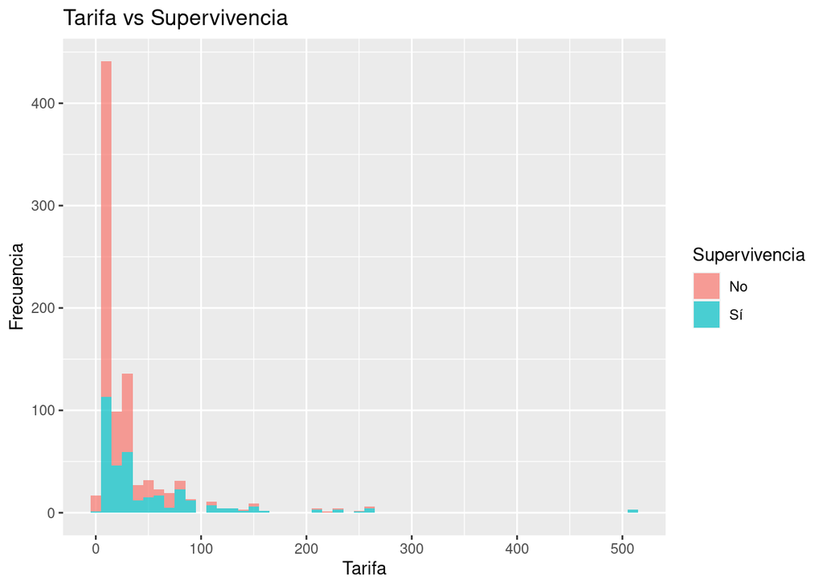

```r
ggplot(data, aes(x = Fare, fill = factor(Survived))) +
  geom_histogram(binwidth = 10, alpha = 0.7) +
  ggtitle('Tarifa vs Supervivencia') +
  xlab('Tarifa') +
  ylab('Frecuencia') +
  scale_fill_discrete(name = "Supervivencia", labels = c("No", "Sí"))
```

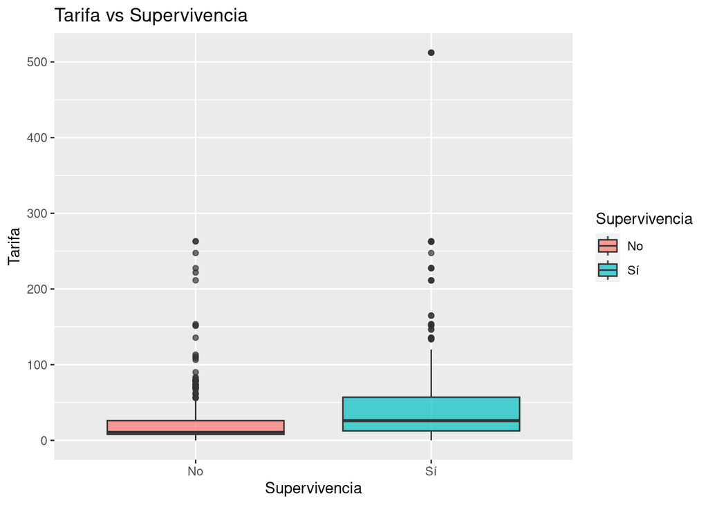

```r
ggplot(data, aes(x = factor(Survived), y = Fare, fill = factor(Survived))) +
  geom_boxplot(alpha = 0.7) +
  ggtitle('Tarifa vs Supervivencia') +
  xlab('Supervivencia') +
  ylab('Tarifa') +
  scale_x_discrete(labels = c("No", "Sí")) +
  scale_fill_discrete(name = "Supervivencia", labels = c("No", "Sí"))
```

Una prueba t nos conduce a que existe una diferencia significativa en las tarifas medias pagadas por los individuos que sobrevivieron y los que no. El valor de t es -6.8391 y el p-valor es practicamente 0, lo que indica que la diferencia es altamente significativa estadísticamente. En promedio, los individuos que sobrevivieron pagaron una tarifa más alta ($48.40) en comparación con los que no sobrevivieron ($22.12).

```r
# Prueba t para comparar las medias de las tarifas entre los que sobrevivieron y los que no
t_test_result <- t.test(Fare ~ Survived, data = data)
t_test_result
```

```
##
##  Welch Two Sample t-test
##
## data:  Fare by Survived
## t = -6.8391, df = 436.7, p-value = 2.699e-11
## alternative hypothesis: true difference in means between group 0 and group 1 is not equal to 0
## 95 percent confidence interval:
##  -33.82912 -18.72592
## sample estimates:
## mean in group 0 mean in group 1
##        22.11789        48.39541
```

### Género vs. superviviencia

¿Será que el género fue significativo?

```r
data %>% names
```

```
##  [1] "PassengerId" "Survived"    "Pclass"      "Name"        "Sex"
##  [6] "Age"         "SibSp"       "Parch"       "Ticket"      "Fare"
## [11] "Cabin"       "Embarked"
```

```r
data <- data %>%
  mutate(Survived = factor(Survived,labels = c("No","Yes")),
         Sex = factor(Sex,labels = c("Female","Male")),
         Pclass = factor(Pclass),
         Child = as.factor(ifelse(Age <= 12,"Yes","No")))
```

```r
attach(data)
tabla_sex <- table(Survived,Sex)
resultado_sex <- chisq.test(tabla_sex) # el género no fue independiente de la tasa de supervivencia
resultado_sex
```

```
##
##  Pearson's Chi-squared test with Yates' continuity correction
##
## data:  tabla_sex
## X-squared = 260.72, df = 1, p-value < 2.2e-16
```

```r
addmargins(tabla_sex)
```

```
##         Sex
## Survived Female Male Sum
##      No      81  468 549
##      Yes    233  109 342
##      Sum    314  577 891
```

### Niños vs. superviviencia

```r
attach(data)
tabla_child <- table(Survived,Child)
resultado_child <- chisq.test(tabla_child) # Los niños sin duda alguna tuvieron más chance de sobrevivir.
resultado_child
```

```
##
##  Pearson's Chi-squared test with Yates' continuity correction
##
## data:  tabla_child
## X-squared = 8.7581, df = 1, p-value = 0.003082
```

```r
addmargins(tabla_child)
```

```
##         Child
## Survived  No Yes Sum
##      No  395  29 424
##      Yes 250  40 290
##      Sum 645  69 714
```

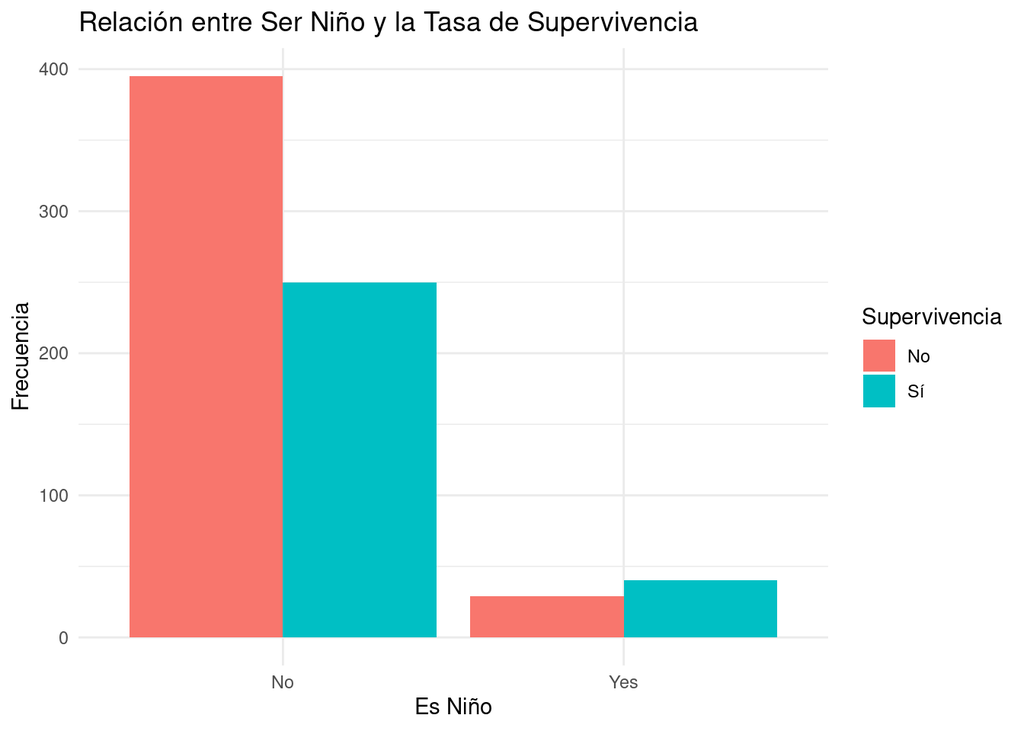

```r
data %>%
  dplyr::select(Child,Survived) %>%
  filter(complete.cases(.)) %>%
  ggplot(aes(x = Child, fill = Survived)) +
  geom_bar(position = "dodge") +
  ggtitle('Relación entre Ser Niño y la Tasa de Supervivencia') +
  xlab('Es Niño') +
  ylab('Frecuencia') +
  scale_fill_discrete(name = "Supervivencia", labels = c("No", "Sí")) +
  theme_minimal()
```

# Modelo Logístico Completo

Aplicamos un modelo de regresión logística utilizando todas las variables disponibles.

```r
#complete_model <- glm(Survived ~ ., data = data, family = binomial)
#summary(complete_model)
```

```r
complete_model <- glm(Survived ~ Pclass + Sex + Age + SibSp + Parch + Fare + Child + Embarked, data = data, family = binomial)
summary(complete_model)
```

```
##
## Call:
## glm(formula = Survived ~ Pclass + Sex + Age + SibSp + Parch +
##     Fare + Child + Embarked, family = binomial, data = data)
##
## Coefficients:
##              Estimate Std. Error z value Pr(>|z|)
## (Intercept)  3.799049   0.560804   6.774 1.25e-11 ***
## Pclass2     -1.073028   0.332510  -3.227 0.001251 **
## Pclass3     -2.235313   0.348340  -6.417 1.39e-10 ***
## SexMale     -2.735815   0.229228 -11.935  < 2e-16 ***
## Age         -0.026493   0.009513  -2.785 0.005355 **
## SibSp       -0.521926   0.143875  -3.628 0.000286 ***
## Parch       -0.181541   0.134612  -1.349 0.177457
## Fare         0.002758   0.002801   0.985 0.324803
## ChildYes     1.581478   0.482738   3.276 0.001053 **
## EmbarkedQ   -0.726291   0.594512  -1.222 0.221837
## EmbarkedS   -0.373447   0.277252  -1.347 0.177994
## ---
## Signif. codes:  0 '***' 0.001 '**' 0.01 '*' 0.05 '.' 0.1 ' ' 1
##
## (Dispersion parameter for binomial family taken to be 1)
##
##     Null deviance: 960.90  on 711  degrees of freedom
## Residual deviance: 621.05  on 701  degrees of freedom
##   (179 observations deleted due to missingness)
## AIC: 643.05
##
## Number of Fisher Scoring iterations: 5
```

# Modelo Logístico Reducido

Identificamos y eliminamos variables no significativas para desarrollar un modelo reducido.

# Step AIC

```r
library(MASS)
data2 <- data %>%
  dplyr::select(Survived,Pclass,Sex,Age,SibSp,Parch,Fare,Child,Embarked) %>%
  filter(complete.cases(.))
complete_model2 <- glm(Survived ~ Pclass + Sex + Age + SibSp + Parch + Fare + Child + Embarked, data = data2, family = binomial)
best_model <- stepAIC(complete_model2)
```

```
## Start:  AIC=643.05
## Survived ~ Pclass + Sex + Age + SibSp + Parch + Fare + Child +
##     Embarked
##
##            Df Deviance    AIC
## - Embarked  2   623.43 641.43
## - Fare      1   622.14 642.14
## - Parch     1   622.95 642.95
## <none>          621.05 643.05
## - Age       1   629.16 649.16
## - Child     1   632.34 652.34
## - SibSp     1   635.95 655.95
## - Pclass    2   666.97 684.97
## - Sex       1   802.19 822.19
##
## Step:  AIC=641.43
## Survived ~ Pclass + Sex + Age + SibSp + Parch + Fare + Child
##
##          Df Deviance    AIC
## - Fare    1   625.11 641.11
## - Parch   1   625.40 641.40
## <none>        623.43 641.43
## - Age     1   632.12 648.12
## - Child   1   635.27 651.27
## - SibSp   1   639.92 655.92
## - Pclass  2   673.46 687.46
## - Sex     1   806.97 822.97
##
## Step:  AIC=641.11
## Survived ~ Pclass + Sex + Age + SibSp + Parch + Child
##
##          Df Deviance    AIC
## - Parch   1   626.32 640.32
## <none>        625.11 641.11
## - Age     1   635.49 649.49
## - Child   1   635.94 649.94
## - SibSp   1   640.50 654.50
## - Pclass  2   724.08 736.08
## - Sex     1   810.52 824.52
##
## Step:  AIC=640.32
## Survived ~ Pclass + Sex + Age + SibSp + Child
##
##          Df Deviance    AIC
## <none>        626.32 640.32
## - Child   1   636.04 648.04
## - Age     1   637.60 649.60
## - SibSp   1   644.28 656.28
## - Pclass  2   726.30 736.30
## - Sex     1   814.98 826.98
```

```r
summary(best_model)
```

```
##
## Call:
## glm(formula = Survived ~ Pclass + Sex + Age + SibSp + Child,
##     family = binomial, data = data2)
##
## Coefficients:
##              Estimate Std. Error z value Pr(>|z|)
## (Intercept)  3.830524   0.469064   8.166 3.18e-16 ***
## Pclass2     -1.361650   0.284249  -4.790 1.66e-06 ***
## Pclass3     -2.583341   0.285105  -9.061  < 2e-16 ***
## SexMale     -2.675279   0.218944 -12.219  < 2e-16 ***
## Age         -0.030330   0.009286  -3.266  0.00109 **
## SibSp       -0.545125   0.137654  -3.960 7.49e-05 ***
## ChildYes     1.401819   0.460508   3.044  0.00233 **
## ---
## Signif. codes:  0 '***' 0.001 '**' 0.01 '*' 0.05 '.' 0.1 ' ' 1
##
## (Dispersion parameter for binomial family taken to be 1)
##
##     Null deviance: 960.90  on 711  degrees of freedom
## Residual deviance: 626.32  on 705  degrees of freedom
## AIC: 640.32
##
## Number of Fisher Scoring iterations: 5
```

# Interpretación de Parámetros

- **`Sexo (SexMale)`:** El coeficiente negativo de -2.675 indica que ser hombre disminuye significativamente la probabilidad de sobrevivir en comparación con ser mujer. Específicamente, la chance de superviviencia se reducirá a un 6.9%.
- **Clase del Pasajero (`Pclass`)**: Los coeficientes negativos para Pclass2 (-1.362) y Pclass3 (-2.583) sugieren que los pasajeros de segunda y tercera clase tienen una probabilidad significativamente menor de sobrevivir en comparación con los de primera clase.
- **Niño (`ChildYes`)**: El coeficiente positivo de 1.402 indica que ser un niño (edad ≤ 12 años) aumenta significativamente la probabilidad de sobrevivir en comparación con no ser un niño.

# Predicción

Hagamos predicciones para dos individuos con características específicas. Creamos para esto un `data.frame` con dos individuos (una mujer de 25 años que viajó en primera clase sin hermanos/cónyuges a bordo y un hombre de 30 años en tercera clase con un hermano/cónyuge a bordo) y predeciremos sus probabilidades de supervivencia utilizando el modelo logístico.

```r
# Creando un data frame con las características de dos individuos
new_data <- data.frame(
  Pclass = factor(c(1, 3), levels = levels(data$Pclass)),
  Sex = factor(c("Female", "Male"), levels = levels(data$Sex)),
  Age = c(25, 30),
  SibSp = c(0, 1),
  Child = factor(c("No", "No"), levels = levels(data$Child))
)

# Haciendo predicciones con el modelo reducido
predictions <- predict(best_model, new_data, type = "response")
predictions
```

```
##          1          2
## 0.95573493 0.05299494
```

Clasificamos si la persona, sobrevivió o no.

```r
ifelse(predictions > 0.5,":D",":(")
```

```
##    1    2
## ":D" ":("
```

Vamos a probar el poder predictivo de nuestro modelo con 20 pasajeros al azar.

```r
#random_data <- data2 %>% sample_frac(0.10) # 10% de la data
random_data <- data2 %>% sample_n(20) # 20 pasajeros

predicciones <- predict(best_model,random_data,
                         type = "response")
#carita <- ifelse(predicciones > 0.5,":D",":(")
carita <- ifelse(predicciones > 0.5,"Yes","No")

pred <- data.frame(real = random_data$Survived,
prediccion = predicciones, situacion = carita)

pred
```

```
##    real prediccion situacion
## 1   Yes 0.10954994        No
## 2    No 0.03851092        No
## 3    No 0.24669956        No
## 4    No 0.16776280        No
## 5    No 0.11254378        No
## 6    No 0.50826181       Yes
## 7    No 0.06559295        No
## 8    No 0.37470733        No
## 9   Yes 0.92605996       Yes
## 10  Yes 0.08327627        No
## 11   No 0.04085260        No
## 12   No 0.56103347       Yes
## 13   No 0.09301846        No
## 14  Yes 0.86905305       Yes
## 15   No 0.62697789       Yes
## 16   No 0.10519021        No
## 17   No 0.05937912        No
## 18  Yes 0.83474625       Yes
## 19   No 0.11560881        No
## 20  Yes 0.73965789       Yes
```

```r
table(pred$real,pred$situacion)
```

```
##
##       No Yes
##   No  11   3
##   Yes  2   4
```

# Conclusiones

A la luz de los números, *¿podemos decir que las cosas sucedieron como en la película?*